# R Notebook

```r
library(here)
library(corrplot)
library(ggbiplot)
library(broom)
library(tidyverse)
library(GGally)

vf <- read_csv(here::here("data/processed/voterfile_combined.csv"))
```

Breakdown of responses, how many with no response

```r
left_join(vf, resp, by = c("state", "test_id")) %>%
  dplyr::count(recall_vote, sort = TRUE)
```

```
# A tibble: 4 x 2
  recall_vote      n
  <chr>        <int>
1 NA          174887
2 Yes           1388
3 No            1288
4 DK             750
```

Yes outnumber the nos, but we have a high rate of don’t know: 0.2205803

how many people do we drop from the responses

```r
anti_join(resp, vf, by = c("state", "test_id")) %>%
  dplyr::count(state, sort = TRUE) %>%
  mutate(sum(n))
```

```
# A tibble: 20 x 2
   state     n
   <chr> <int>
 1 CO      260
 2 CA        6
 3 AZ        4
 4 NY        3
 5 WA        3
 6 WI        3
 7 NA        3
 8 AL        2
 9 ID        2
10 SC        2
11 AK        1
12 FL        1
13 GA        1
14 IL        1
15 KS        1
16 LA        1
17 ME        1
18 MO        1
19 NM        1
20 OR        1
```

298 are dropped, 38 because they are out of state

## breakdown of demographics in the district

missingness in the voterfile

```r
miss <- lapply(vf, function(x) sum(is.na(x)))

miss[miss > 0]
```

```
$ca_age
[1] 11

$co_find
[1] 26680

$es_genrate
[1] 1421

$hh_ageavg
[1] 9

$hh_children
[1] 8490

$density_cluster
[1] 14331

$member_type_status
[1] 167634

$bach_or_higher
[1] 42368

$some_college
[1] 42368

$asian
[1] 42368

$black
[1] 42368

$native_american
[1] 42368

$other_race
[1] 42368

$pacific_islander
[1] 42368

$two_or_more_races
[1] 42368

$white
[1] 42368
```

11 missing age, 9 missing household age, quite a few missing modeled household income, NA for hh_children does not mean 0 here, density cluster also missing quite a bit; could this be filled in by census tract?

party affiliation

```r
dplyr::count(vf, ca_partyaffiliation, sort = TRUE)
```

```
# A tibble: 7 x 2
  ca_partyaffiliation     n
  <chr>               <int>
1 DEM                 71575
2 NPA                 61329
3 REP                 42824
4 LIB                  1219
5 OTH                   533
6 GRE                   529
7 UNK                   304
```

```r
dplyr::count(vf, district, ca_partyaffiliation) %>%
  spread(district, n)
```

```
# A tibble: 7 x 3
  ca_partyaffiliation  `03`  `11`
  <chr>               <int> <int>
1 DEM                 43991 27584
2 GRE                   180   349
3 LIB                   442   777
4 NPA                 28998 32331
5 OTH                   222   311
6 REP                 21990 20834
7 UNK                   174   130
```

political activity of population

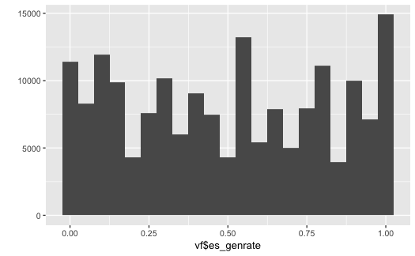

```r
qplot(vf$es_genrate, binwidth = .05)
```

```r
dplyr::count(vf, es_anyprimary)
```

```
# A tibble: 2 x 2
  es_anyprimary      n
  <chr>          <int>
1 N             122404
2 Y              55909
```

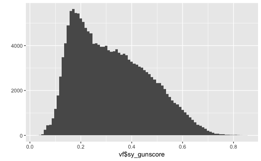

```r
qplot(vf$sy_gunscore, binwidth = .01)
```

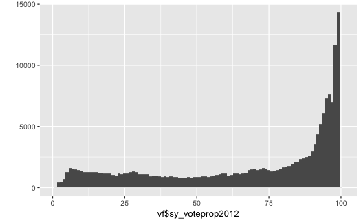

```r
qplot(vf$sy_voteprop2012, binwidth = 1)
```

### ACS

```r
#
# train %>%
#   select(53:68) %>%
#   ggpairs()\
```

## comparing demos to outcome

```r
train %>%
  group_by(ca_partyaffiliation) %>%
  dplyr::count(recall_vote, sort = TRUE) %>%
  mutate(pct_party = n / sum(n))
```

| ca_partyaffiliation | recall_vote | n | pct_party |
| --- | --- | --- | --- |
| DEM | No | 662 | 0.2395946435 |
| REP | Yes | 522 | 0.1889250814 |
| NPA | Yes | 301 | 0.1089395585 |
| DEM | Yes | 266 | 0.0962721679 |
| NPA | No | 255 | 0.0922909881 |
| DEM | DK | 238 | 0.0861382555 |
| NPA | DK | 231 | 0.0836047774 |
| REP | No | 125 | 0.0452406804 |
| REP | DK | 107 | 0.0387260224 |
| LIB | DK | 10 | 0.0036192544 |

[output cut: 11 more lines]

```r
NA
```

Reps more strongly favor recall than Dems oppose; NPA also more strongly support recall; key question is what to do with the don’t knows.

responses by district

```r
train %>%
  group_by(district) %>%
  dplyr::count(recall_vote, sort = TRUE) %>%
  mutate(dist_pct = n / sum(n))
```

| district | recall_vote | n | dist_pct |
| --- | --- | --- | --- |
| 11 | Yes | 578 | 0.20919291 |
| 11 | No | 545 | 0.19724937 |
| 03 | Yes | 529 | 0.19145856 |
| 03 | No | 515 | 0.18639160 |
| 11 | DK | 363 | 0.13137894 |
| 03 | DK | 233 | 0.08432863 |

Despite district 3 having higher dem pct, 1 point in favor of recall with less uncertainty

Plotting some of the relationships

```r
num_plots <- train %>%
  select_if(is.numeric) %>%
  select(-starts_with("ac"), -1, -3, -5, -6, -recall_binary,
         -di_statehousedistrict) %>%
  mutate(log_density = log(pop_density))
```

```
NaNs produced
```

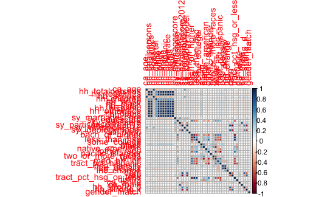

```r
correlations <- cor(num_plots, use = "pairwise.complete.obs")

corrplot(correlations)
```

it looks like we can caputre more of the variable with three sections:

- household info
- acs info
- ideology

some of the modeled variables are correlated with acs info

In addition, recall most strongly correlated with partisan vote score and ideaology, so probably ony need one of those

state house district has a strong relationship with race

## PCA

```r
pca_comp <- num_plots %>%
  filter(!is.na(hh_children), !is.na(bach_or_higher), !is.na(log_density))

dat_pca <- prcomp(pca_comp, center = TRUE, scale. = TRUE)

summary(dat_pca)
```

```
Importance of components:
                          PC1    PC2    PC3     PC4     PC5     PC6     PC7
Standard deviation     3.1547 2.4600 2.2274 1.76259 1.55262 1.36813 1.32388
Proportion of Variance 0.2262 0.1375 0.1128 0.07061 0.05479 0.04254 0.03983
Cumulative Proportion  0.2262 0.3637 0.4765 0.54708 0.60187 0.64441 0.68424
                           PC8     PC9    PC10   PC11    PC12    PC13
Standard deviation     1.14246 1.09661 1.00555 0.9905 0.96223 0.94766
Proportion of Variance 0.02966 0.02733 0.02298 0.0223 0.02104 0.02041
Cumulative Proportion  0.71390 0.74124 0.76422 0.7865 0.80755 0.82797
                          PC14    PC15    PC16    PC17    PC18    PC19
Standard deviation     0.91139 0.85687 0.83691 0.80091 0.75989 0.74022
Proportion of Variance 0.01888 0.01669 0.01592 0.01458 0.01312 0.01245
Cumulative Proportion  0.84684 0.86353 0.87945 0.89403 0.90715 0.91960
                          PC20   PC21    PC22    PC23    PC24    PC25
Standard deviation     0.69681 0.6798 0.61136 0.57248 0.54416 0.51650
Proportion of Variance 0.01104 0.0105 0.00849 0.00745 0.00673 0.00606
Cumulative Proportion  0.93064 0.9411 0.94964 0.95709 0.96382 0.96988
                         PC26    PC27    PC28    PC29    PC30    PC31
Standard deviation     0.5009 0.44344 0.43069 0.39135 0.34923 0.33097
Proportion of Variance 0.0057 0.00447 0.00422 0.00348 0.00277 0.00249
Cumulative Proportion  0.9756 0.98005 0.98427 0.98775 0.99052 0.99301
                          PC32    PC33    PC34    PC35    PC36    PC37
Standard deviation     0.31913 0.31231 0.19229 0.18165 0.15346 0.11283
Proportion of Variance 0.00231 0.00222 0.00084 0.00075 0.00054 0.00029
Cumulative Proportion  0.99532 0.99754 0.99838 0.99913 0.99967 0.99996
                          PC38    PC39     PC40      PC41      PC42
Standard deviation     0.03883 0.02054 0.006543 1.635e-15 9.427e-16
Proportion of Variance 0.00003 0.00001 0.000000 0.000e+00 0.000e+00
Cumulative Proportion  0.99999 1.00000 1.000000 1.000e+00 1.000e+00
                            PC43      PC44
Standard deviation     4.608e-16 2.133e-16
Proportion of Variance 0.000e+00 0.000e+00
Cumulative Proportion  1.000e+00 1.000e+00
```

```r
tidied_pca <- broom::tidy(dat_pca$rotation) %>%
  gather(pc, contribution, PC1:PC36)
```

```
'tidy.matrix' is deprecated.
See help("Deprecated")
```

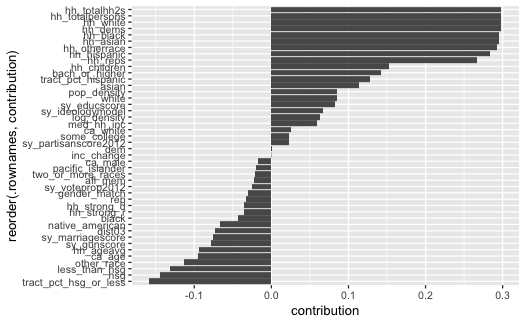

```r
tidied_pca %>%
  filter(pc == "PC1") %>%
  ggplot(aes(reorder(.rownames, contribution), contribution)) +
    geom_col() +
    coord_flip()
```

again, it looks like houshold info and acs data on education are contributing to the most amount of variation

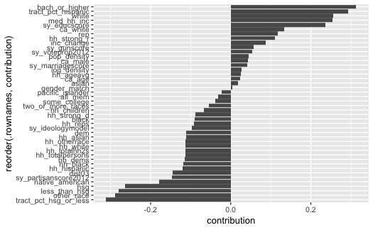

```r
tidied_pca %>%
  filter(pc == "PC2") %>%
  ggplot(aes(reorder(.rownames, contribution), contribution)) +
    geom_col() +
    coord_flip()
```

race starts to play a higher role here

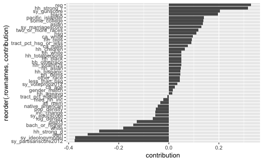

```r
tidied_pca %>%
  filter(pc == "PC3") %>%
  ggplot(aes(reorder(.rownames, contribution), contribution)) +
    geom_col() +
    coord_flip()
```